# Class Slides

22 September 2022

```r
knitr::opts_chunk$set(echo = FALSE)
```

## Really Getting our R on

Chapter 27 of *R for Data Science* introduces us to this function.

You’ll be submitting an R Markdown file next week for DAM1

## What we’ll cover today

- Chapter 8 Workflow: projects
- Chapter 6 Workflow: scripts
- Chapter 27 R Markdown
- Thorndike page 40, 46 & 47
- Boxplots
- Data-analytic Memo #1

## Chapter 8 Workflow: projects

There’s some introductory notes about “what is real?” and “where does my data live?”. But the advice that they are conveying really starts in section 8.4 RStudio projects

They suggest creating a new project in a new directory. When you do this, RStudio creates a folder on your computer. You can also do this with Finder (if you are a Mac person). It’s been a while since I used a PC, but there’s got to be a similar way.

## Your turn

Let’s take a minute to make sure everyone can do this part. I’ll show you on my own computer, too.

## Chapter 6 Workflow: scripts

So far you’ve been using the console to run code. That’s a great place to start, but you’ll find it gets cramped pretty quickly as you create more complex ggplot2 graphics and dplyr pipes. To give yourself more room to work, it’s a great idea to use the script editor. Open it up either by clicking the File menu, and selecting New File, then R script, or using the keyboard shortcut Cmd/Ctrl + Shift + N. Now you’ll see four panes:

## Your turn again

Let’s take a minute to make sure everyone can do this part. I’ll show you on my own computer, too.

## Chapter 27 R Markdown

27.1.1 Prerequisites You need the rmarkdown package, but you don’t need to explicitly install it or load it, as RStudio automatically does both when needed.

## 27.2.1 Exercises

1. Create a new R Markdown document with File > New File > R Markdown… Knit it by clicking the appropriate button. Knit it by using the appropriate keyboard short cut. Verify that you can modify the input and see the output update.

Show this to everyone, Hoffman…

## Thorndike page 40, 46 & 47

Before you work on DAM1, you should read pages 39 - 56 of the Thorndike PDFs (assigned for Tuesday, Sept 27)

In DAM 1, I’ve asked you to produce a several (many) Boxplots

```r
## LOAD PACKAGES
library(tidyverse)
```

## READ IN DATA (from your own computer)

```r
Table.2.1 <- read_csv(file = "Table.2.1_clean.csv")
```

## The Table.2.1 tibble

This is an electronic version of what the Thorndike book printed on pages 24 & 25 with numbers for Gender and Class replaced

```r
Table.2.1
```

```
## # A tibble: 52 × 7
##    First    Last     Gender Class   Reading Spelling  Math
##    <chr>    <chr>    <chr>  <chr>     <dbl>    <dbl> <dbl>
##  1 Aaron    Andrews  male   Johnson      32       64    43
##  2 Byron    Biggs    male   Johnson      40       64    37
##  3 Charles  Cowen    male   Johnson      36       40    38
##  4 Donna    Davis    female Johnson      41       74    40
##  5 Erin     Edwards  female Johnson      36       69    28
##  6 Fernando Franco   male   Johnson      41       67    42
##  7 Gail     Galaraga female Johnson      40       71    37
##  8 Harpo    Henry    male   Johnson      30       51    34
##  9 Irrida   Ignacio  female Johnson      37       68    35
## 10 Jack     Johanson male   Johnson      26       56    26
## # … with 42 more rows
```

## Boxplots (and 3.9 stuff)

For review (or if you haven’t encountered them before), boxplots summarize the distribution of a continuous variable. A boxplots displays five summary statistics: the median (shown as a line), the first and third quartile (the box) and two whiskers showing the extent of data 1.5 IQR beyond the box, and any “outlying” points individually. (no outliers in the Spelling data here)

## A boxplot of “Spelling”

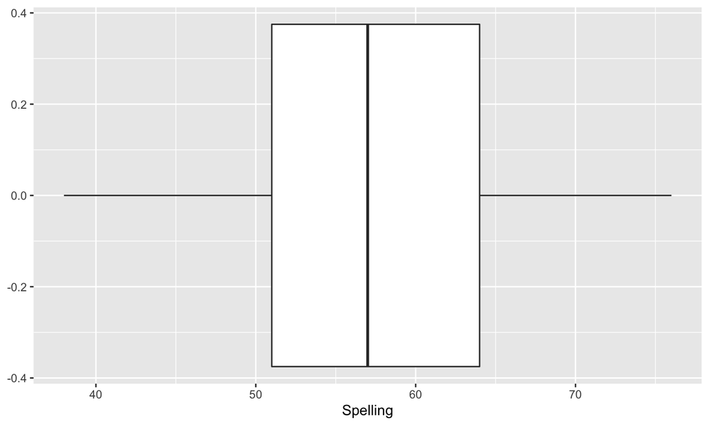

```r
ggplot(data = Table.2.1, mapping = aes(x = Spelling)) +
  geom_boxplot()
```

## grouped by classroom teacher

This shows that Ms Johnson’s class has a higher median Spelling score (64) than Mr. Cordero’s class (53).

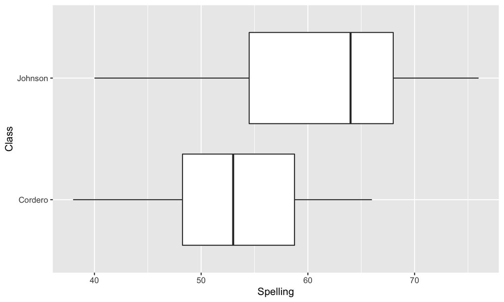

```r
ggplot(data = Table.2.1, mapping = aes(x = Class, y = Spelling)) +
  geom_boxplot() +
  coord_flip() # Make Spelling the x variable and Class the y variable
```

## What’s the IQR?

If we sorted a column from smallest to largest, the middle data point is the the median: the value that separates the top half from the bottom half.

If we cut the bottom half in half, that spot is the 25th percentile.

And if we cut the top half in half, that spot is the 75th percentile.

## For spelling

The 25 percentile is 51. The Median is 57. And the 75th percentile is 64.

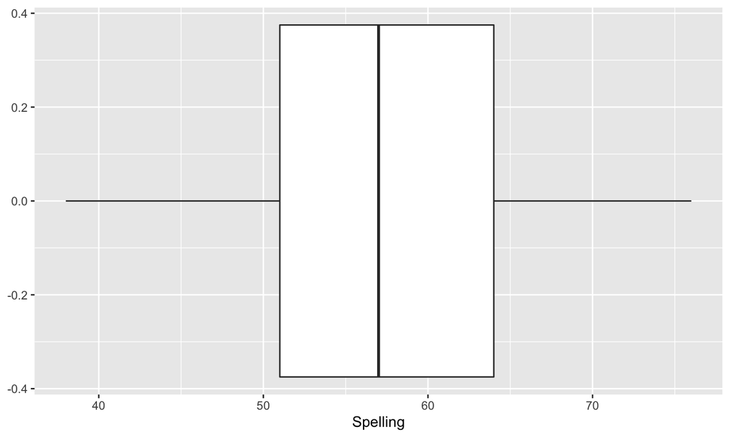

```r
ggplot(data = Table.2.1, mapping = aes(x = Spelling)) +
  geom_boxplot()
```